# 📘 **Guía para la Visualización de Resultados en Árboles de Decisión con Python, Scikit-learn y Matplotlib**

### **Aplicaciones en Machine Learning y Educación en Ingeniería de Datos**

### 👨‍🏫 **Autores:**

**Carlos Andrés Tamayo Benjumea**  
Ingeniero de Sistemas | Docente Universitario  
**José Javier Coronel Casadiego**  
Ingeniero de Sistemas | Especialista en Docencia Universitaria | Docente Universitario

### 🛠️ **Herramientas Utilizadas:**

- Python
- Google Colab
- Scikit-learn
- Matplotlib

### 🎯 **Propósito:**

Desarrollar y visualizar modelos de **Árboles de Decisión** para clasificación supervisada mediante herramientas de Python, aplicando buenas prácticas didácticas para su uso en ingeniería, análisis de datos y educación en machine learning.

### 📅 **Fecha:**

22 de Julio de 2025

# 📒 Clasificación con Árboles de Decisión en Machine Learning

## Guía paso a paso con Python, Classification Report y Matriz de Confusión

🎯 **Objetivo:** Aprender a entrenar, evaluar e interpretar un modelo de Árbol de Decisión para tareas de clasificación con sklearn.

## 🌳 Introducción a los Árboles de Decisión

Los **Árboles de Decisión** son modelos ampliamente utilizados en Machine Learning supervisado para problemas de clasificación y regresión. Estos modelos funcionan dividiendo recursivamente el espacio de las características en regiones más homogéneas respecto a la variable objetivo, siguiendo una estructura jerárquica similar a un árbol.

Su principal ventaja radica en la **interpretabilidad** del modelo: es posible visualizar el conjunto de decisiones que lleva a cada predicción. Además, no requieren normalización previa de los datos ni suposiciones de distribución.

En clasificación, los árboles asignan una clase a cada hoja del árbol, basándose en medidas de pureza como el **Gini Index** o la **Entropía**. El entrenamiento busca minimizar la impureza dentro de cada subconjunto resultante en cada división.

### **Características Principales:**

- No requieren normalización de datos.
- Interpretables y fáciles de visualizar.
- Pueden sobreajustarse si no se controlan parámetros como la profundidad máxima.

# 📘 Árbol de Decisión para Clasificación con Python y Scikit-learn

## Aplicaciones en Educación, Ingeniería y Ciencia de Datos

Este notebook muestra de forma didáctica cómo implementar un modelo de **Árbol de Decisión** para tareas de clasificación supervisada en Machine Learning.  
Incluye:

- Exploración visual de datos
- Entrenamiento del modelo
- Evaluación con métricas y visualización
- Interpretación pedagógica de resultados

## 🔧 Librerías y Herramientas Utilizadas

- `pandas`: manipulación de datos tabulares
- `matplotlib`, `seaborn`: visualización gráfica
- `sklearn`: Machine Learning (Árboles de decisión, métricas, datasets)

Estas librerías son fundamentales en proyectos de Machine Learning supervisado.

```python
import pandas as pd
import matplotlib.pyplot as plt
import seaborn as sns
from sklearn.datasets import load_iris
from sklearn.model_selection import train_test_split
from sklearn.tree import DecisionTreeClassifier, plot_tree
from sklearn.metrics import classification_report, confusion_matrix, accuracy_score
```

```python
# Cargar el dataset Iris integrado en sklearn
iris = load_iris(as_frame=True)
X = iris.data
y = iris.target
df = iris.frame

# Visualizar las primeras filas del conjunto de datos
df.head()
```

|  | sepal length (cm) | sepal width (cm) | petal length (cm) | petal width (cm) | target |
| --- | --- | --- | --- | --- | --- |
| 0 | 5.1 | 3.5 | 1.4 | 0.2 | 0 |
| 1 | 4.9 | 3.0 | 1.4 | 0.2 | 0 |
| 2 | 4.7 | 3.2 | 1.3 | 0.2 | 0 |
| 3 | 4.6 | 3.1 | 1.5 | 0.2 | 0 |
| 4 | 5.0 | 3.6 | 1.4 | 0.2 | 0 |

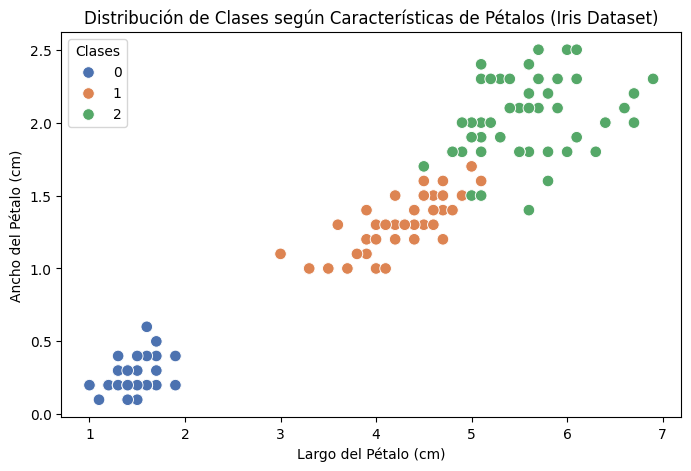

```python
# Gráfica para explorar la relación entre largo y ancho del pétalo
plt.figure(figsize=(8, 5))
sns.scatterplot(
    x=df["petal length (cm)"],
    y=df["petal width (cm)"],
    hue=df["target"],
    palette="deep",
    s=70
)
plt.title("Distribución de Clases según Características de Pétalos (Iris Dataset)")
plt.xlabel("Largo del Pétalo (cm)")
plt.ylabel("Ancho del Pétalo (cm)")
plt.legend(title="Clases")
plt.show()
```

🔍 Esta gráfica nos permite identificar si las clases son separables visualmente en este conjunto de características.

```python
X_train, X_test, y_train, y_test = train_test_split(
    X, y, test_size=0.3, random_state=42
)

print(f"🔹 Tamaño de entrenamiento: {X_train.shape}")
print(f"🔹 Tamaño de prueba: {X_test.shape}")
```

```
🔹 Tamaño de entrenamiento: (105, 4)
🔹 Tamaño de prueba: (45, 4)
```

📑 Dividimos el dataset en 70% para entrenamiento y 30% para prueba, siguiendo buenas prácticas para evaluar la generalización del modelo.

```python
dtree = DecisionTreeClassifier(random_state=42)
dtree.fit(X_train, y_train)
```

```
DecisionTreeClassifier(random_state=42)
```

🎯 Entrenamos un **Árbol de Decisión** con los datos de entrenamiento. El modelo genera reglas de decisión que permiten clasificar las muestras según las características.

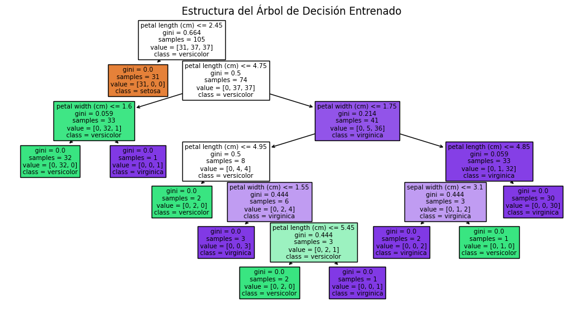

```python
plt.figure(figsize=(12, 6))
plot_tree(dtree, feature_names=X.columns, class_names=iris.target_names, filled=True)
plt.title("Estructura del Árbol de Decisión Entrenado")
plt.show()
```

Visualizamos la estructura del árbol para interpretar cómo el modelo toma decisiones basadas en los atributos del conjunto de datos.

```python
y_pred = dtree.predict(X_test)

print("✅ Accuracy:", accuracy_score(y_test, y_pred))
print("\n📄 Classification Report:\n", classification_report(y_test, y_pred))
print("\n🔢 Confusion Matrix:\n", confusion_matrix(y_test, y_pred))
```

```
✅ Accuracy: 1.0

📄 Classification Report:
               precision    recall  f1-score   support

           0       1.00      1.00      1.00        19
           1       1.00      1.00      1.00        13
           2       1.00      1.00      1.00        13

    accuracy                           1.00        45
   macro avg       1.00      1.00      1.00        45
weighted avg       1.00      1.00      1.00        45


🔢 Confusion Matrix:
 [[19  0  0]
 [ 0 13  0]
 [ 0  0 13]]
```

📊 Evaluamos el rendimiento del modelo utilizando:

- **Accuracy**: porcentaje global de aciertos.
- **Classification Report**: métricas por clase (precisión, recall, F1-score).
- **Matriz de Confusión**: errores y aciertos por clase.

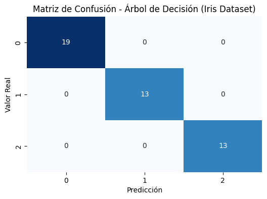

```python
cm = confusion_matrix(y_test, y_pred)
plt.figure(figsize=(6, 4))
sns.heatmap(cm, annot=True, fmt="d", cmap="Blues", cbar=False)
plt.xlabel("Predicción")
plt.ylabel("Valor Real")
plt.title("Matriz de Confusión - Árbol de Decisión (Iris Dataset)")
plt.show()
```

🎨 La matriz de confusión facilita la comprensión visual de los errores cometidos y refuerza la interpretación de las métricas numéricas.

## 📝 Conclusiones

✔️ El **Árbol de Decisión** ha demostrado ser un modelo sencillo y efectivo para clasificación en datasets educativos como Iris.  
✔️ Su estructura permite entender claramente cómo se toman las decisiones de clasificación.  
✔️ Es importante complementar las métricas cuantitativas con visualizaciones para obtener un análisis más completo.  
✔️ Esta plantilla puede ser adaptada a otros algoritmos como KNN, SVM o Random Forest, siguiendo la misma estructura pedagógica.